# Ex17 Paté

PIE2

Tardor 2019-2020

### En un tast de patés, cada persona del panell ha tastat i puntuat 5 patés. Per a no influir sobre el sobre les persones del panell, els patés es varen presentar de forma aleatòria i identificats amb codis numèrics que indueixin a ser ordenats. En el fitxer “pate.csv” hi ha els resultats del tast, les seves columnes són:

**• tastador**

**• codi del paté**

**– les valoracions de la qualitat de: color, aroma, textura, sabor i la ordenació. Les puntuacions són de 0 a 10 i l’ordenació és en ordre de preferència ( de 1 a 5). Calculeu també la valoració global que és la mitjana de les de color, aroma, textura i sabor.**

*Directori de treball, llegir dades, calcular global i definir factors*

```r
#setwd("...")
library(car)
library(emmeans)
library(tables)
dd<-read.csv2("../Dades/pate.csv")
head(dd)
```

```
##   per pate color aroma text sabor ordre
## 1   1  113     4     4    5     7     4
## 2   1  140     4     4    5     4     5
## 3   1  220     7     7    7     7     2
## 4   1  372     6     8    7     8     1
## 5   1  525     7     7    7     6     3
## 6   2  113     4     4    5     5     4
```

```r
dd$global<-(dd$color+dd$aroma+dd$text+dd$sabor)/4
dd$pate<-as.factor(dd$pate)
dd$per<-as.factor(dd$per)
head(dd)
```

```
##   per pate color aroma text sabor ordre global
## 1   1  113     4     4    5     7     4   5.00
## 2   1  140     4     4    5     4     5   4.25
## 3   1  220     7     7    7     7     2   7.00
## 4   1  372     6     8    7     8     1   7.25
## 5   1  525     7     7    7     6     3   6.75
## 6   2  113     4     4    5     5     4   4.50
```

*Descriptiva*

```r
print(tabular(mean*(global+aroma+text+sabor+ordre)*pate~(1+per),dd),justification="r")
```

```
##
##                          per
##              pate   All    1    2    3    4    5    6    7    8
##  mean global  113 5.625 5.00 4.50 7.75 6.00 4.75 5.25 6.00 5.75
##               140 5.156 4.25 4.25 7.50 5.75 5.50 4.25 6.50 3.25
##               220 5.719 7.00 5.00 6.25 5.75 6.25 4.75 5.50 5.25
##               372 6.500 7.25 5.50 7.00 6.00 7.50 6.00 7.75 5.00
##               525 6.156 6.75 5.75 5.75 6.25 4.75 5.75 7.75 6.50
##        aroma  113 5.000 4.00 4.00 8.00 5.00 5.00 4.00 6.00 4.00
##               140 4.250 4.00 4.00 6.00 4.00 4.00 3.00 6.00 3.00
##               220 5.875 7.00 5.00 7.00 6.00 7.00 4.00 5.00 6.00
##               372 6.500 8.00 5.00 7.00 7.00 7.00 4.00 8.00 6.00
##               525 5.875 7.00 5.00 6.00 6.00 4.00 4.00 8.00 7.00
##         text  113 6.250 5.00 5.00 7.00 7.00 6.00 6.00 7.00 7.00
##               140 6.000 5.00 5.00 9.00 7.00 7.00 5.00 7.00 3.00
##               220 5.625 7.00 4.00 7.00 5.00 6.00 6.00 6.00 4.00
##               372 6.375 7.00 6.00 8.00 4.00 8.00 7.00 7.00 4.00
##               525 6.125 7.00 6.00 5.00 6.00 6.00 6.00 7.00 6.00
##        sabor  113 6.250 7.00 5.00 8.00 7.00 4.00 6.00 6.00 7.00
##               140 5.625 4.00 4.00 7.00 7.00 7.00 5.00 8.00 3.00
##               220 5.250 7.00 5.00 5.00 6.00 7.00 5.00 3.00 4.00
##               372 6.625 8.00 6.00 6.00 7.00 8.00 6.00 8.00 4.00
##               525 6.000 6.00 6.00 6.00 6.00 4.00 6.00 8.00 6.00
##        ordre  113 3.375 4.00 4.00 1.00 3.00 5.00 4.00 4.00 2.00
##               140 3.750 5.00 5.00 2.00 2.00 3.00 5.00 3.00 5.00
##               220 3.125 2.00 2.00 4.00 4.00 2.00 3.00 5.00 3.00
##               372 2.000 1.00 3.00 3.00 1.00 1.00 2.00 1.00 4.00
##               525 2.750 3.00 1.00 5.00 5.00 4.00 1.00 2.00 1.00
```

#### **a) Per la valoració global, plantegeu el model lineal amb el factors paté. Suposant que es compleixen les condicions per fer el test anova, amb =0.05 i contrastant els tests adequats, contesteu:**

**i. Els patés tenen algun efecte sobre la valoració?**

```r
#Model
mg1<-lm(global~pate,data=dd)

#Model nul
mg0<-lm(global~1,data=dd)

Anova(mg1)
```

```
## Anova Table (Type II tests)
##
## Response: global
##           Sum Sq Df F value Pr(>F)
## pate       8.509  4  1.9703 0.1206
## Residuals 37.789 35
```

**ii. Si és el cas, feu-ne les comparacions múltiples i interpreteu els resultats.**

*Comparacions múltiples de fet no cal fer-les*

```r
(emm1<-emmeans(mg1,~pate))
```

```
##  pate emmean    SE df lower.CL upper.CL
##  113    5.62 0.367 35     4.88     6.37
##  140    5.16 0.367 35     4.41     5.90
##  220    5.72 0.367 35     4.97     6.46
##  372    6.50 0.367 35     5.75     7.25
##  525    6.16 0.367 35     5.41     6.90
##
## Confidence level used: 0.95
```

```r
#pairs(emm)
CLD(emm1)
```

```
##  pate emmean    SE df lower.CL upper.CL .group
##  140    5.16 0.367 35     4.41     5.90  1
##  113    5.62 0.367 35     4.88     6.37  1
##  220    5.72 0.367 35     4.97     6.46  1
##  525    6.16 0.367 35     5.41     6.90  1
##  372    6.50 0.367 35     5.75     7.25  1
##
## Confidence level used: 0.95
## P value adjustment: tukey method for comparing a family of 5 estimates
## significance level used: alpha = 0.05
```

**iii. Creus que es compleixen les condicions del test anova? Justifiqueu-ho teòricament i amb gràfics de diagnòstic.**

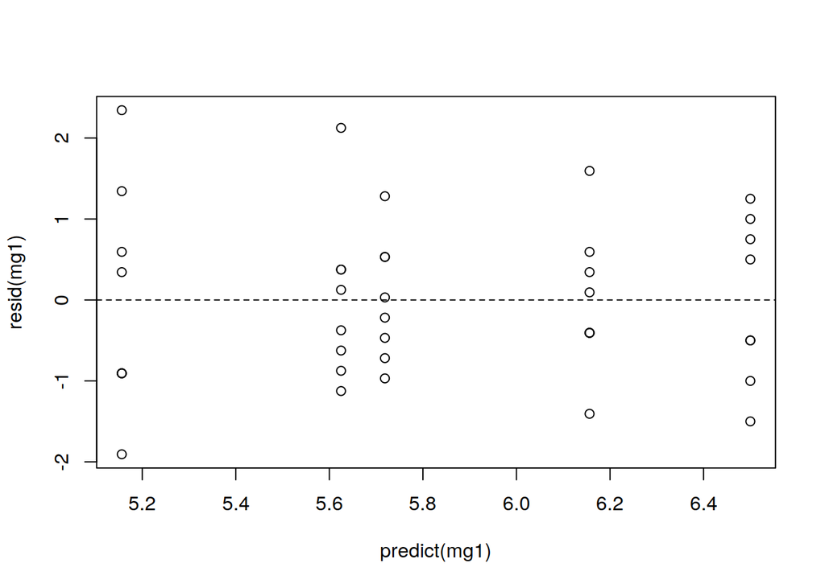

```r
plot(predict(mg1),resid(mg1))
abline(h=0,lty=2)
```

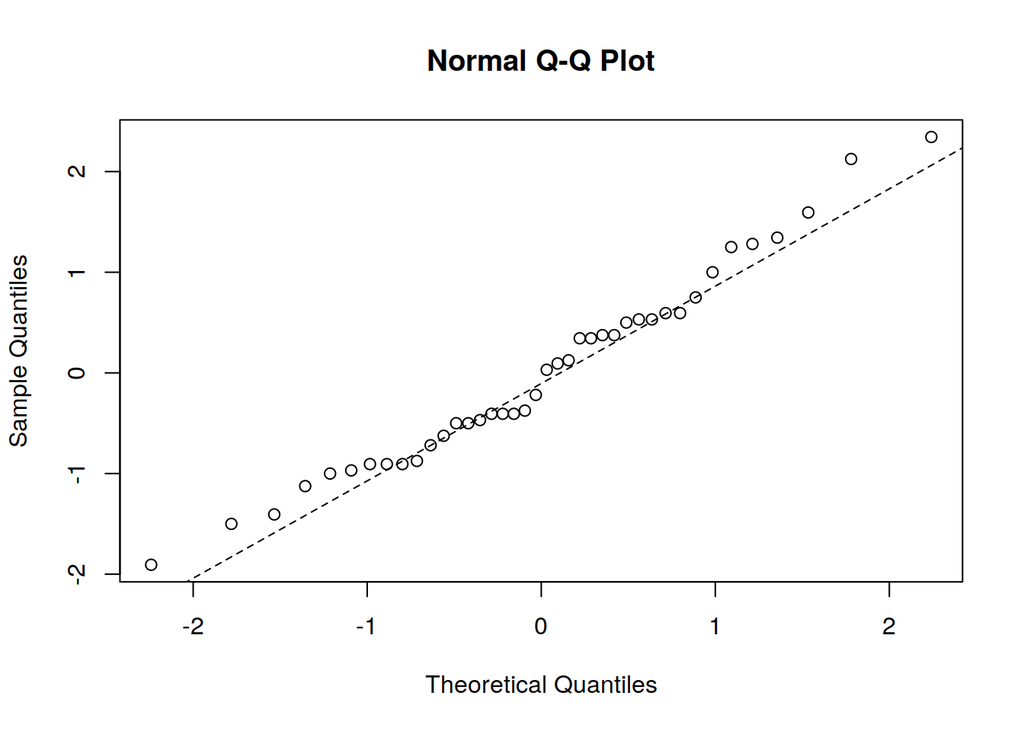

```r
qqnorm(resid(mg1))
qqline(resid(mg1),lt=2)
```

#### **b) També per la valoració global, plantegeu el model lineal additiu amb els factors tastador i paté. Suposant que es compleixen les condicions per fer el test anova, amb =0.05 i contrastant els tests adequats, contesteu:**

**i. Els patés i/o els tastadors tenen algun efecte sobre la valoració?**

*Models i Test omnibus*

```r
#Model
mg<-lm(global~pate+per,data=dd)

#Model nul ja està fet
#mg0<-lm(global~1,data=dd)

anova(mg0,mg)
```

```
## Analysis of Variance Table
##
## Model 1: global ~ 1
## Model 2: global ~ pate + per
##   Res.Df    RSS Df Sum of Sq      F   Pr(>F)
## 1     39 46.298
## 2     28 20.716 11    25.583 3.1435 0.007009 **
## ---
## Signif. codes:  0 '***' 0.001 '**' 0.01 '*' 0.05 '.' 0.1 ' ' 1
```

**ii. Els patés tenen algun efecte sobre la valoració?**

*Test anova*

```r
Anova(mg)
```

```
## Anova Table (Type II tests)
##
## Response: global
##            Sum Sq Df F value  Pr(>F)
## pate       8.5094  4  2.8754 0.04104 *
## per       17.0734  7  3.2967 0.01101 *
## Residuals 20.7156 28
## ---
## Signif. codes:  0 '***' 0.001 '**' 0.01 '*' 0.05 '.' 0.1 ' ' 1
```

**iii. Si és el cas, feu-ne les comparacions múltiples i interpreteu els resultats.**

*Comparacions múltiples*

```r
(emm<-emmeans(mg,~pate))
```

```
##  pate emmean    SE df lower.CL upper.CL
##  113    5.62 0.304 28     5.00     6.25
##  140    5.16 0.304 28     4.53     5.78
##  220    5.72 0.304 28     5.10     6.34
##  372    6.50 0.304 28     5.88     7.12
##  525    6.16 0.304 28     5.53     6.78
##
## Results are averaged over the levels of: per
## Confidence level used: 0.95
```

```r
#pairs(emm)
CLD(emm)
```

```
##  pate emmean    SE df lower.CL upper.CL .group
##  140    5.16 0.304 28     4.53     5.78  1
##  113    5.62 0.304 28     5.00     6.25  12
##  220    5.72 0.304 28     5.10     6.34  12
##  525    6.16 0.304 28     5.53     6.78  12
##  372    6.50 0.304 28     5.88     7.12   2
##
## Results are averaged over the levels of: per
## Confidence level used: 0.95
## P value adjustment: tukey method for comparing a family of 5 estimates
## significance level used: alpha = 0.05
```

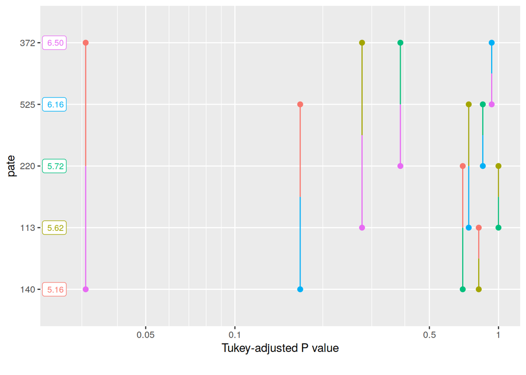

```r
pwpp(emm)
```

**iv. Compareu els resultats dels apartats anterior amb els que s’obtindrien si ho féssim amb el model de només factor paté, sense tenir en compte els tastadors.**

*Models i Test omnibus dels 2 models*

```r
#Model
anova(mg0,mg)
```

```
## Analysis of Variance Table
##
## Model 1: global ~ 1
## Model 2: global ~ pate + per
##   Res.Df    RSS Df Sum of Sq      F   Pr(>F)
## 1     39 46.298
## 2     28 20.716 11    25.583 3.1435 0.007009 **
## ---
## Signif. codes:  0 '***' 0.001 '**' 0.01 '*' 0.05 '.' 0.1 ' ' 1
```

```r
anova(mg0,mg1)
```

```
## Analysis of Variance Table
##
## Model 1: global ~ 1
## Model 2: global ~ pate
##   Res.Df    RSS Df Sum of Sq      F Pr(>F)
## 1     39 46.298
## 2     35 37.789  4    8.5094 1.9703 0.1206
```

*Test anova dels 2 models. Fixeu-vos amb la suma dels efectes Per+Residuals*

```r
Anova(mg)
```

```
## Anova Table (Type II tests)
##
## Response: global
##            Sum Sq Df F value  Pr(>F)
## pate       8.5094  4  2.8754 0.04104 *
## per       17.0734  7  3.2967 0.01101 *
## Residuals 20.7156 28
## ---
## Signif. codes:  0 '***' 0.001 '**' 0.01 '*' 0.05 '.' 0.1 ' ' 1
```

```r
Anova(mg1)
```

```
## Anova Table (Type II tests)
##
## Response: global
##           Sum Sq Df F value Pr(>F)
## pate       8.509  4  1.9703 0.1206
## Residuals 37.789 35
```

*Comparacions múltiples*

```r
CLD(emm)
```

```
##  pate emmean    SE df lower.CL upper.CL .group
##  140    5.16 0.304 28     4.53     5.78  1
##  113    5.62 0.304 28     5.00     6.25  12
##  220    5.72 0.304 28     5.10     6.34  12
##  525    6.16 0.304 28     5.53     6.78  12
##  372    6.50 0.304 28     5.88     7.12   2
##
## Results are averaged over the levels of: per
## Confidence level used: 0.95
## P value adjustment: tukey method for comparing a family of 5 estimates
## significance level used: alpha = 0.05
```

```r
CLD(emm1)
```

```
##  pate emmean    SE df lower.CL upper.CL .group
##  140    5.16 0.367 35     4.41     5.90  1
##  113    5.62 0.367 35     4.88     6.37  1
##  220    5.72 0.367 35     4.97     6.46  1
##  525    6.16 0.367 35     5.41     6.90  1
##  372    6.50 0.367 35     5.75     7.25  1
##
## Confidence level used: 0.95
## P value adjustment: tukey method for comparing a family of 5 estimates
## significance level used: alpha = 0.05
```

**v. Creus que es compleixen les condicions del test anova? Justifiqueu-ho teòricament i amb gràfics de diagnòstic.**

*Diagnòstics*

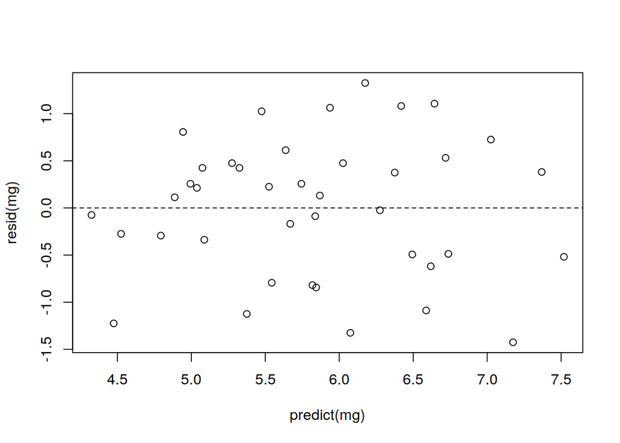

```r
plot(predict(mg),resid(mg))
abline(h=0,lty=2)
```

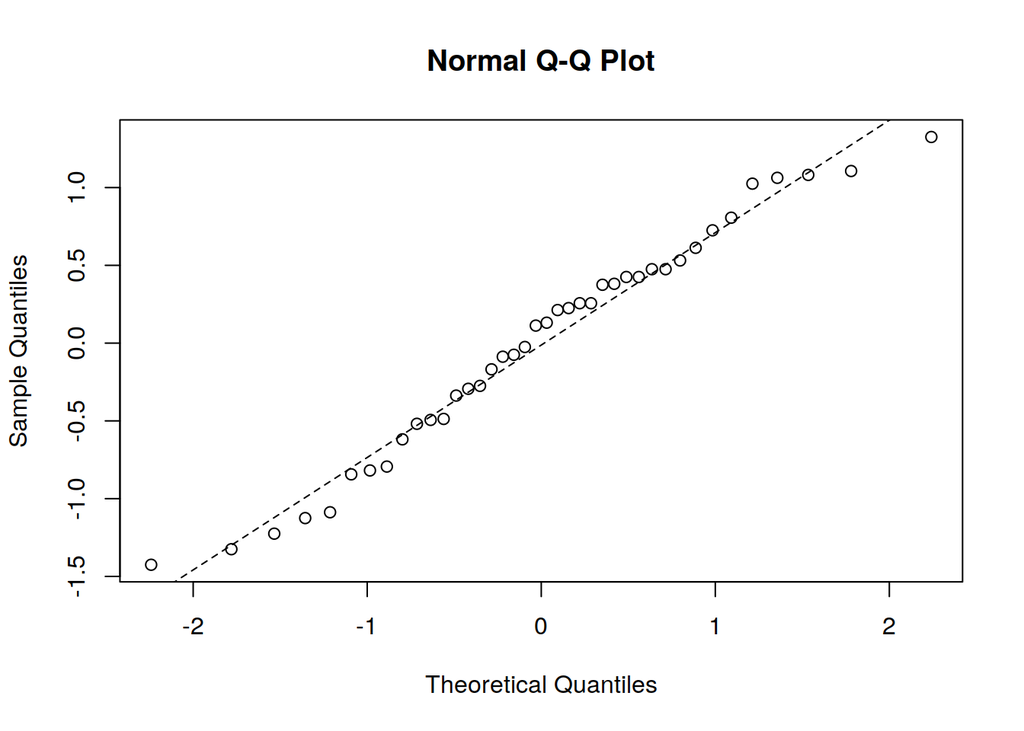

```r
qqnorm(resid(mg))
qqline(resid(mg),lt=2)
```

#### c) (Optatiu) Per les valoracions de color, aroma, textura i sabor, feu els apartats anteriors a) i b).**

#### *Feu-les vosaltres*

***d) Per la variàble ordenació dieu perquè no es compleixen les condicions dels models lineals.**

*Nota: Aquest cas cas és molt diferent de les altres valoracions, però el model dels dos factors lineal és una versió asimptòtica del test (no paramètric) de Friedmann.*

#### *Els valors de la ordenació no són independents*

#### *e) Pel model lineal additiu de dos factors de l’apartat b):*

**i. Escriviu a mà la matriu del model.**

```r
summary(dd)
```

```
##       per      pate       color         aroma          text
##  1      : 5   113:8   Min.   :4.0   Min.   :3.0   Min.   :3.000
##  2      : 5   140:8   1st Qu.:5.0   1st Qu.:4.0   1st Qu.:5.000
##  3      : 5   220:8   Median :6.0   Median :5.5   Median :6.000
##  4      : 5   372:8   Mean   :5.8   Mean   :5.5   Mean   :6.075
##  5      : 5   525:8   3rd Qu.:7.0   3rd Qu.:7.0   3rd Qu.:7.000
##  6      : 5           Max.   :8.0   Max.   :8.0   Max.   :9.000
##  (Other):10
##      sabor          ordre       global
##  Min.   :3.00   Min.   :1   Min.   :3.250
##  1st Qu.:5.00   1st Qu.:2   1st Qu.:5.000
##  Median :6.00   Median :3   Median :5.750
##  Mean   :5.95   Mean   :3   Mean   :5.831
##  3rd Qu.:7.00   3rd Qu.:4   3rd Qu.:6.500
##  Max.   :8.00   Max.   :5   Max.   :7.750
##
```

```r
n.pates<-5
n.per<-8
#Terme independent->columna de 1'ns
#Patès->Id de 5 sense la primera columna
mpate<-diag(5)[,-1]
dimnames(mpate)<-list(paste0("pate",1:5),paste0("alpha",2:5))
mpate
```

```
##       alpha2 alpha3 alpha4 alpha5
## pate1      0      0      0      0
## pate2      1      0      0      0
## pate3      0      1      0      0
## pate4      0      0      1      0
## pate5      0      0      0      1
```

```r
mper<-diag(8)[,-1]
dimnames(mper)<-list(paste0("per",1:8),paste0("beta",2:8))
mper
```

```
##      beta2 beta3 beta4 beta5 beta6 beta7 beta8
## per1     0     0     0     0     0     0     0
## per2     1     0     0     0     0     0     0
## per3     0     1     0     0     0     0     0
## per4     0     0     1     0     0     0     0
## per5     0     0     0     1     0     0     0
## per6     0     0     0     0     1     0     0
## per7     0     0     0     0     0     1     0
## per8     0     0     0     0     0     0     1
```

**ii. Comproveu que és la matriu que utilitza l’R.**

```r
mod<-lm(global~pate+per,x=T,data=dd)
mod$x
```

```
##    (Intercept) pate140 pate220 pate372 pate525 per2 per3 per4 per5 per6 per7
## 1            1       0       0       0       0    0    0    0    0    0    0
## 2            1       1       0       0       0    0    0    0    0    0    0
## 3            1       0       1       0       0    0    0    0    0    0    0
## 4            1       0       0       1       0    0    0    0    0    0    0
## 5            1       0       0       0       1    0    0    0    0    0    0
## 6            1       0       0       0       0    1    0    0    0    0    0
## 7            1       1       0       0       0    1    0    0    0    0    0
## 8            1       0       1       0       0    1    0    0    0    0    0
## 9            1       0       0       1       0    1    0    0    0    0    0
## 10           1       0       0       0       1    1    0    0    0    0    0
## 11           1       0       0       0       0    0    1    0    0    0    0
## 12           1       1       0       0       0    0    1    0    0    0    0
## 13           1       0       1       0       0    0    1    0    0    0    0
## 14           1       0       0       1       0    0    1    0    0    0    0
```

[output cut: 75 more lines]